# INN Hotels Project

### Removing insignificant variables (p-value > 0.05 )

```python
# let's print the logistic regression summary
print(lg0.summary())
```

```
                           Logit Regression Results
==============================================================================
Dep. Variable:         booking_status   No. Observations:                25392
Model:                          Logit   Df Residuals:                    25368
Method:                           MLE   Df Model:                           23
Date:                Fri, 27 Jan 2023   Pseudo R-squ.:                  0.2888
Time:                        22:45:36   Log-Likelihood:                -11422.
converged:                       True   LL-Null:                       -16060.
Covariance Type:            nonrobust   LLR p-value:                     0.000
========================================================================================================
                                           coef    std err          z      P>|z|      [0.025      0.975]
--------------------------------------------------------------------------------------------------------
const                                -1221.1273    118.069    -10.342      0.000   -1452.539    -989.716
no_of_adults                             0.1249      0.036      3.515      0.000       0.055       0.195
no_of_children                           0.2409      0.056      4.279      0.000       0.131       0.351
no_of_weekend_nights                     0.2006      0.019     10.513      0.000       0.163       0.238
no_of_week_nights                        0.0618      0.012      5.209      0.000       0.039       0.085
required_car_parking_space              -1.3954      0.134    -10.436      0.000      -1.657      -1.133
lead_time                                0.0138      0.000     56.960      0.000       0.013       0.014
arrival_year                             0.6032      0.059     10.308      0.000       0.488       0.718
arrival_month                           -0.0506      0.006     -8.018      0.000      -0.063      -0.038
arrival_date                             0.0039      0.002      2.096      0.036       0.000       0.008
repeated_guest                          -1.7135      0.606     -2.826      0.005      -2.902      -0.525
no_of_previous_cancellations             0.3172      0.101      3.137      0.002       0.119       0.515
no_of_previous_bookings_not_canceled    -1.6192      0.987     -1.641      0.101      -3.554       0.315
avg_price_per_room                       0.0224      0.001     30.952      0.000       0.021       0.024
no_of_special_requests                  -1.1847      0.028    -42.955      0.000      -1.239      -1.131
type_of_meal_plan_Meal Plan 2           -0.3562      0.063     -5.685      0.000      -0.479      -0.233
type_of_meal_plan_Meal Plan 3            1.6155      2.260      0.715      0.475      -2.815       6.046
type_of_meal_plan_Not Selected           0.7593      0.049     15.393      0.000       0.663       0.856
room_type_reserved_Room_Type 2           0.0828      0.127      0.652      0.514      -0.166       0.332
room_type_reserved_Room_Type 3           0.5005      1.116      0.449      0.654      -1.686       2.687
room_type_reserved_Room_Type 4           0.0302      0.050      0.600      0.549      -0.068       0.129
room_type_reserved_Room_Type 5          -0.8144      0.204     -3.993      0.000      -1.214      -0.415
room_type_reserved_Room_Type 6          -0.9765      0.145     -6.720      0.000      -1.261      -0.692
room_type_reserved_Room_Type 7          -1.6688      0.296     -5.638      0.000      -2.249      -1.089
========================================================================================================
```

Observation: Some of our dummy variables have high P-values, but at least one or more in each set is significant, so we will keep them.

```python
# Outside of the dummy variables, the highest P-value we will drop is no_of_previous_bookings_not_canceled
X_train1 = X_train0.drop("no_of_previous_bookings_not_canceled", axis=1)
```

```python
# fitting the model on training set
logit1 = sm.Logit(y_train, X_train1.astype(float))
lg1 = logit1.fit()

pred_train1 = lg1.predict(X_train1)
pred_train1 = np.round(pred_train1)


print("Accuracy on training set : ", accuracy_score(y_train, pred_train1))
```

```
Optimization terminated successfully.
         Current function value: 0.450024
         Iterations 11
Accuracy on training set :  0.7900126023944549
```

Observation: There is no significant change to the model performance and there are no additional values to drop as all other P-values are below 0.05, with the exception of our dummy variables which will stay.

## Final Model Summary

```python
# checking summary of the model
print(lg1.summary())
```

```
                           Logit Regression Results
==============================================================================
Dep. Variable:         booking_status   No. Observations:                25392
Model:                          Logit   Df Residuals:                    25369
Method:                           MLE   Df Model:                           22
Date:                Fri, 27 Jan 2023   Pseudo R-squ.:                  0.2885
Time:                        22:45:52   Log-Likelihood:                -11427.
converged:                       True   LL-Null:                       -16060.
Covariance Type:            nonrobust   LLR p-value:                     0.000
==================================================================================================
                                     coef    std err          z      P>|z|      [0.025      0.975]
--------------------------------------------------------------------------------------------------
const                          -1215.4089    118.090    -10.292      0.000   -1446.860    -983.957
no_of_adults                       0.1257      0.036      3.537      0.000       0.056       0.195
no_of_children                     0.2414      0.056      4.287      0.000       0.131       0.352
no_of_weekend_nights               0.2005      0.019     10.509      0.000       0.163       0.238
no_of_week_nights                  0.0621      0.012      5.227      0.000       0.039       0.085
required_car_parking_space        -1.3933      0.134    -10.424      0.000      -1.655      -1.131
lead_time                          0.0138      0.000     57.086      0.000       0.013       0.014
arrival_year                       0.6003      0.059     10.258      0.000       0.486       0.715
arrival_month                     -0.0506      0.006     -8.021      0.000      -0.063      -0.038
arrival_date                       0.0038      0.002      2.051      0.040       0.000       0.008
repeated_guest                    -2.7103      0.479     -5.658      0.000      -3.649      -1.771
no_of_previous_cancellations       0.2513      0.077      3.256      0.001       0.100       0.403
avg_price_per_room                 0.0225      0.001     31.007      0.000       0.021       0.024
no_of_special_requests            -1.1860      0.028    -42.997      0.000      -1.240      -1.132
type_of_meal_plan_Meal Plan 2     -0.3578      0.063     -5.709      0.000      -0.481      -0.235
type_of_meal_plan_Meal Plan 3      1.5956      2.242      0.712      0.477      -2.800       5.991
type_of_meal_plan_Not Selected     0.7616      0.049     15.440      0.000       0.665       0.858
room_type_reserved_Room_Type 2     0.0826      0.127      0.650      0.516      -0.166       0.332
room_type_reserved_Room_Type 3     0.5000      1.116      0.448      0.654      -1.687       2.687
room_type_reserved_Room_Type 4     0.0296      0.050      0.587      0.557      -0.069       0.128
room_type_reserved_Room_Type 5    -0.8168      0.204     -4.006      0.000      -1.216      -0.417
room_type_reserved_Room_Type 6    -0.9794      0.145     -6.738      0.000      -1.264      -0.695
room_type_reserved_Room_Type 7    -1.6730      0.296     -5.652      0.000      -2.253      -1.093
==================================================================================================
```

Observations:

### Converting coefficients to odds

- The coefficients of the logistic regression model are in terms of log(odd), to find the odds we have to take the exponential of the coefficients.
- Therefore, **odds = exp(b)**
- The percentage change in odds is given as **odds = (exp(b) - 1) * 100**

```python
# converting coefficients to odds
odds = np.exp(lg1.params)

# adding the odds to a dataframe
pd.DataFrame(odds, X_train1.columns, columns=["odds"])
```

|  | odds |
| --- | --- |
| const | 0.00000 |
| no_of_adults | 1.13400 |
| no_of_children | 1.27306 |
| no_of_weekend_nights | 1.22206 |
| no_of_week_nights | 1.06404 |
| required_car_parking_space | 0.24824 |
| lead_time | 1.01389 |
| arrival_year | 1.82270 |
| arrival_month | 0.95066 |
| arrival_date | 1.00385 |
| repeated_guest | 0.06652 |
| no_of_previous_cancellations | 1.28565 |
| avg_price_per_room | 1.02270 |
| no_of_special_requests | 0.30544 |
| type_of_meal_plan_Meal Plan 2 | 0.69923 |
| type_of_meal_plan_Meal Plan 3 | 4.93120 |
| type_of_meal_plan_Not Selected | 2.14177 |
| room_type_reserved_Room_Type 2 | 1.08609 |
| room_type_reserved_Room_Type 3 | 1.64870 |
| room_type_reserved_Room_Type 4 | 1.03000 |
| room_type_reserved_Room_Type 5 | 0.44183 |
| room_type_reserved_Room_Type 6 | 0.37554 |
| room_type_reserved_Room_Type 7 | 0.18768 |

```python
# finding the percentage change
perc_change_odds = (np.exp(lg1.params) - 1) * 100

# adding the change_odds% to a dataframe
pd.DataFrame(perc_change_odds, X_train1.columns, columns=["change_odds%"])
```

|  | change_odds% |
| --- | --- |
| const | -100.00000 |
| no_of_adults | 13.39952 |
| no_of_children | 27.30611 |
| no_of_weekend_nights | 22.20609 |
| no_of_week_nights | 6.40370 |
| required_car_parking_space | -75.17561 |
| lead_time | 1.38879 |
| arrival_year | 82.27043 |
| arrival_month | -4.93407 |
| arrival_date | 0.38485 |
| repeated_guest | -93.34830 |
| no_of_previous_cancellations | 28.56531 |
| avg_price_per_room | 2.27042 |
| no_of_special_requests | -69.45590 |
| type_of_meal_plan_Meal Plan 2 | -30.07679 |
| type_of_meal_plan_Meal Plan 3 | 393.11964 |
| type_of_meal_plan_Not Selected | 114.17746 |
| room_type_reserved_Room_Type 2 | 8.60888 |
| room_type_reserved_Room_Type 3 | 64.86960 |
| room_type_reserved_Room_Type 4 | 3.00038 |
| room_type_reserved_Room_Type 5 | -55.81664 |
| room_type_reserved_Room_Type 6 | -62.44615 |
| room_type_reserved_Room_Type 7 | -81.23205 |

Coefficient Interpretations - some interesting ones:

- no_of_adults: Holding all other features constant, a unit change in # of adults will increase the odds of cancellation by ~13%
- required_car_parking_space: Holding all other features constant, a unit change in required car parking space will decrease the odds of cancellation by ~75%
- type_of_meal_plan_Meal_Plan_3: Holding all other features constant, a unit change in meal plan 3 will increase the odds of cancellation by ~393%!
- And finally, some room types like 2, 3, & 4 will increase the odds of cancellation, but others like 5, 6, & 7 will decrease the odds of cancellation.

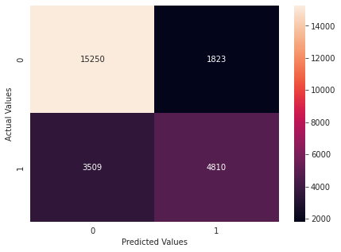

```python
# confusion matrix on final model - lg1
cm = confusion_matrix(y_train, pred_train1)
plt.figure(figsize=(7, 5))
sns.heatmap(cm, annot=True, fmt="g")
plt.xlabel("Predicted Values")
plt.ylabel("Actual Values")
plt.show()
```

```python
# accuracy on training set
print("Accuracy on training set : ", accuracy_score(y_train, pred_train1))
```

```
Accuracy on training set :  0.7900126023944549
```

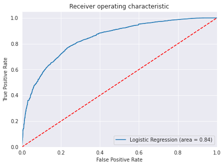

```python
# ROC-AUC on training set
logit_roc_auc_train = roc_auc_score(y_train, lg1.predict(X_train1))
fpr, tpr, thresholds = roc_curve(y_train, lg1.predict(X_train1))
plt.figure(figsize=(7, 5))
plt.plot(fpr, tpr, label="Logistic Regression (area = %0.2f)" % logit_roc_auc_train)
plt.plot([0, 1], [0, 1], "r--")
plt.xlim([0.0, 1.0])
plt.ylim([0.0, 1.05])
plt.xlabel("False Positive Rate")
plt.ylabel("True Positive Rate")
plt.title("Receiver operating characteristic")
plt.legend(loc="lower right")
plt.show()
```

Observation: the model is performing pretty well on the training set.

### Let's use our model to make predictions on the test data

```python
# dropping variables from test set as well which were dropped from training set
X_test = X_test.drop(['market_segment_type_Complementary','market_segment_type_Corporate','market_segment_type_Offline','market_segment_type_Online','no_of_previous_bookings_not_canceled'], axis=1)
```

```python
pred_test = lg1.predict(X_test) > 0.5
pred_test = np.round(pred_test)
```

```python
print("Accuracy on training set : ", accuracy_score(y_train, pred_train1))
print("Accuracy on test set : ", accuracy_score(y_test, pred_test))
```

```
Accuracy on training set :  0.7900126023944549
Accuracy on test set :  0.7878342368832123
```

```python
# print recall
print("Recall on training set : ", recall_score(y_train, pred_train1))
print("Recall on test set : ", recall_score(y_test, pred_test))
```

```
Recall on training set :  0.5781944945305926
Recall on test set :  0.5757150869321368
```

Observation: Logistic Regression has given a generalized performance on training and test set.

### Changing the threshold to observe performance changes

```python
pred_test = lg1.predict(X_test) > 0.6
pred_test = np.round(pred_test)
```

```python
print("Accuracy on training set : ", accuracy_score(y_train, pred_train1))
print("Accuracy on test set : ", accuracy_score(y_test, pred_test))
```

```
Accuracy on training set :  0.7900126023944549
Accuracy on test set :  0.7839750068914821
```

```python
# print recall
print("Recall on training set : ", recall_score(y_train, pred_train1))
print("Recall on test set : ", recall_score(y_test, pred_test))
```

```
Recall on training set :  0.5781944945305926
Recall on test set :  0.46719012899607404
```

Observation: Increasing the threshold from 0.5 to 0.6 decreases the accuracy on the test set ever so slightly, but signficantly impacts recall. Since we want to mazimize recall, we will stick to the 0.5 threshold as the better model.

## Building a Decision Tree model

### Importing additional packages

```python
# import decision tree packages
from sklearn.tree import DecisionTreeClassifier
from sklearn import tree

# To tune different models
from sklearn.model_selection import GridSearchCV

# Removes the limit for the number of displayed columns
pd.set_option("display.max_columns", None)
# Sets the limit for the number of displayed rows
pd.set_option("display.max_rows", 200)
# setting the precision of floating numbers to 5 decimal points
pd.set_option("display.float_format", lambda x: "%.5f" % x)
```

### Feature Engineering

We will do some of the same feature engineering as for the logistic regression model, but perform them on the datacopy so that we don't have to drop the first of each of the dummy variables.

```python
# drop columns with only unique values
datacopy.Booking_ID.nunique()
```

```
36275
```

```python
datacopy = datacopy.drop(["Booking_ID"], axis=1)
datacopy.head()
```

|  | no_of_adults | no_of_children | no_of_weekend_nights | no_of_week_nights | type_of_meal_plan | required_car_parking_space | room_type_reserved | lead_time | arrival_year | arrival_month | arrival_date | market_segment_type | repeated_guest | no_of_previous_cancellations | no_of_previous_bookings_not_canceled | avg_price_per_room | no_of_special_requests | booking_status |
| --- | --- | --- | --- | --- | --- | --- | --- | --- | --- | --- | --- | --- | --- | --- | --- | --- | --- | --- |
| 0 | 2 | 0 | 1 | 2 | Meal Plan 1 | 0 | Room_Type 1 | 224 | 2017 | 10 | 2 | Offline | 0 | 0 | 0 | 65.00000 | 0 | Not_Canceled |
| 1 | 2 | 0 | 2 | 3 | Not Selected | 0 | Room_Type 1 | 5 | 2018 | 11 | 6 | Online | 0 | 0 | 0 | 106.68000 | 1 | Not_Canceled |
| 2 | 1 | 0 | 2 | 1 | Meal Plan 1 | 0 | Room_Type 1 | 1 | 2018 | 2 | 28 | Online | 0 | 0 | 0 | 60.00000 | 0 | Canceled |
| 3 | 2 | 0 | 0 | 2 | Meal Plan 1 | 0 | Room_Type 1 | 211 | 2018 | 5 | 20 | Online | 0 | 0 | 0 | 100.00000 | 0 | Canceled |
| 4 | 2 | 0 | 1 | 1 | Not Selected | 0 | Room_Type 1 | 48 | 2018 | 4 | 11 | Online | 0 | 0 | 0 | 94.50000 | 0 | Canceled |

```python
# convert categorical variables to dummies but don't drop first value
datacopy = pd.get_dummies(datacopy, columns=["type_of_meal_plan"])
datacopy.head()
```

|  | no_of_adults | no_of_children | no_of_weekend_nights | no_of_week_nights | required_car_parking_space | room_type_reserved | lead_time | arrival_year | arrival_month | arrival_date | market_segment_type | repeated_guest | no_of_previous_cancellations | no_of_previous_bookings_not_canceled | avg_price_per_room | no_of_special_requests | booking_status | type_of_meal_plan_Meal Plan 1 | type_of_meal_plan_Meal Plan 2 | type_of_meal_plan_Meal Plan 3 | type_of_meal_plan_Not Selected |
| --- | --- | --- | --- | --- | --- | --- | --- | --- | --- | --- | --- | --- | --- | --- | --- | --- | --- | --- | --- | --- | --- |
| 0 | 2 | 0 | 1 | 2 | 0 | Room_Type 1 | 224 | 2017 | 10 | 2 | Offline | 0 | 0 | 0 | 65.00000 | 0 | Not_Canceled | 1 | 0 | 0 | 0 |
| 1 | 2 | 0 | 2 | 3 | 0 | Room_Type 1 | 5 | 2018 | 11 | 6 | Online | 0 | 0 | 0 | 106.68000 | 1 | Not_Canceled | 0 | 0 | 0 | 1 |
| 2 | 1 | 0 | 2 | 1 | 0 | Room_Type 1 | 1 | 2018 | 2 | 28 | Online | 0 | 0 | 0 | 60.00000 | 0 | Canceled | 1 | 0 | 0 | 0 |
| 3 | 2 | 0 | 0 | 2 | 0 | Room_Type 1 | 211 | 2018 | 5 | 20 | Online | 0 | 0 | 0 | 100.00000 | 0 | Canceled | 1 | 0 | 0 | 0 |
| 4 | 2 | 0 | 1 | 1 | 0 | Room_Type 1 | 48 | 2018 | 4 | 11 | Online | 0 | 0 | 0 | 94.50000 | 0 | Canceled | 0 | 0 | 0 | 1 |

```python
# convert room type reserved
datacopy = pd.get_dummies(datacopy, columns=["room_type_reserved"])
datacopy.head()
```

|  | no_of_adults | no_of_children | no_of_weekend_nights | no_of_week_nights | required_car_parking_space | lead_time | arrival_year | arrival_month | arrival_date | market_segment_type | repeated_guest | no_of_previous_cancellations | no_of_previous_bookings_not_canceled | avg_price_per_room | no_of_special_requests | booking_status | type_of_meal_plan_Meal Plan 1 | type_of_meal_plan_Meal Plan 2 | type_of_meal_plan_Meal Plan 3 | type_of_meal_plan_Not Selected | room_type_reserved_Room_Type 1 | room_type_reserved_Room_Type 2 | room_type_reserved_Room_Type 3 | room_type_reserved_Room_Type 4 | room_type_reserved_Room_Type 5 | room_type_reserved_Room_Type 6 | room_type_reserved_Room_Type 7 |
| --- | --- | --- | --- | --- | --- | --- | --- | --- | --- | --- | --- | --- | --- | --- | --- | --- | --- | --- | --- | --- | --- | --- | --- | --- | --- | --- | --- |
| 0 | 2 | 0 | 1 | 2 | 0 | 224 | 2017 | 10 | 2 | Offline | 0 | 0 | 0 | 65.00000 | 0 | Not_Canceled | 1 | 0 | 0 | 0 | 1 | 0 | 0 | 0 | 0 | 0 | 0 |
| 1 | 2 | 0 | 2 | 3 | 0 | 5 | 2018 | 11 | 6 | Online | 0 | 0 | 0 | 106.68000 | 1 | Not_Canceled | 0 | 0 | 0 | 1 | 1 | 0 | 0 | 0 | 0 | 0 | 0 |
| 2 | 1 | 0 | 2 | 1 | 0 | 1 | 2018 | 2 | 28 | Online | 0 | 0 | 0 | 60.00000 | 0 | Canceled | 1 | 0 | 0 | 0 | 1 | 0 | 0 | 0 | 0 | 0 | 0 |
| 3 | 2 | 0 | 0 | 2 | 0 | 211 | 2018 | 5 | 20 | Online | 0 | 0 | 0 | 100.00000 | 0 | Canceled | 1 | 0 | 0 | 0 | 1 | 0 | 0 | 0 | 0 | 0 | 0 |
| 4 | 2 | 0 | 1 | 1 | 0 | 48 | 2018 | 4 | 11 | Online | 0 | 0 | 0 | 94.50000 | 0 | Canceled | 0 | 0 | 0 | 1 | 1 | 0 | 0 | 0 | 0 | 0 | 0 |

```python
# convert market segment type
datacopy = pd.get_dummies(datacopy, columns=["market_segment_type"])
datacopy.head()
```

|  | no_of_adults | no_of_children | no_of_weekend_nights | no_of_week_nights | required_car_parking_space | lead_time | arrival_year | arrival_month | arrival_date | repeated_guest | no_of_previous_cancellations | no_of_previous_bookings_not_canceled | avg_price_per_room | no_of_special_requests | booking_status | type_of_meal_plan_Meal Plan 1 | type_of_meal_plan_Meal Plan 2 | type_of_meal_plan_Meal Plan 3 | type_of_meal_plan_Not Selected | room_type_reserved_Room_Type 1 | room_type_reserved_Room_Type 2 | room_type_reserved_Room_Type 3 | room_type_reserved_Room_Type 4 | room_type_reserved_Room_Type 5 | room_type_reserved_Room_Type 6 | room_type_reserved_Room_Type 7 | market_segment_type_Aviation | market_segment_type_Complementary | market_segment_type_Corporate | … |
| --- | --- | --- | --- | --- | --- | --- | --- | --- | --- | --- | --- | --- | --- | --- | --- | --- | --- | --- | --- | --- | --- | --- | --- | --- | --- | --- | --- | --- | --- | --- |
| 0 | 2 | 0 | 1 | 2 | 0 | 224 | 2017 | 10 | 2 | 0 | 0 | 0 | 65.00000 | 0 | Not_Canceled | 1 | 0 | 0 | 0 | 1 | 0 | 0 | 0 | 0 | 0 | 0 | 0 | 0 | 0 | … |
| 1 | 2 | 0 | 2 | 3 | 0 | 5 | 2018 | 11 | 6 | 0 | 0 | 0 | 106.68000 | 1 | Not_Canceled | 0 | 0 | 0 | 1 | 1 | 0 | 0 | 0 | 0 | 0 | 0 | 0 | 0 | 0 | … |
| 2 | 1 | 0 | 2 | 1 | 0 | 1 | 2018 | 2 | 28 | 0 | 0 | 0 | 60.00000 | 0 | Canceled | 1 | 0 | 0 | 0 | 1 | 0 | 0 | 0 | 0 | 0 | 0 | 0 | 0 | 0 | … |
| 3 | 2 | 0 | 0 | 2 | 0 | 211 | 2018 | 5 | 20 | 0 | 0 | 0 | 100.00000 | 0 | Canceled | 1 | 0 | 0 | 0 | 1 | 0 | 0 | 0 | 0 | 0 | 0 | 0 | 0 | 0 | … |
| 4 | 2 | 0 | 1 | 1 | 0 | 48 | 2018 | 4 | 11 | 0 | 0 | 0 | 94.50000 | 0 | Canceled | 0 | 0 | 0 | 1 | 1 | 0 | 0 | 0 | 0 | 0 | 0 | 0 | 0 | 0 | … |

```python
# change the booking_status to 1/0
datacopy.replace({'Canceled': 1, 'Not_Canceled': 0}, inplace=True)
datacopy.head()
```

|  | no_of_adults | no_of_children | no_of_weekend_nights | no_of_week_nights | required_car_parking_space | lead_time | arrival_year | arrival_month | arrival_date | repeated_guest | no_of_previous_cancellations | no_of_previous_bookings_not_canceled | avg_price_per_room | no_of_special_requests | booking_status | type_of_meal_plan_Meal Plan 1 | type_of_meal_plan_Meal Plan 2 | type_of_meal_plan_Meal Plan 3 | type_of_meal_plan_Not Selected | room_type_reserved_Room_Type 1 | room_type_reserved_Room_Type 2 | room_type_reserved_Room_Type 3 | room_type_reserved_Room_Type 4 | room_type_reserved_Room_Type 5 | room_type_reserved_Room_Type 6 | room_type_reserved_Room_Type 7 | market_segment_type_Aviation | market_segment_type_Complementary | market_segment_type_Corporate | … |
| --- | --- | --- | --- | --- | --- | --- | --- | --- | --- | --- | --- | --- | --- | --- | --- | --- | --- | --- | --- | --- | --- | --- | --- | --- | --- | --- | --- | --- | --- | --- |
| 0 | 2 | 0 | 1 | 2 | 0 | 224 | 2017 | 10 | 2 | 0 | 0 | 0 | 65.00000 | 0 | 0 | 1 | 0 | 0 | 0 | 1 | 0 | 0 | 0 | 0 | 0 | 0 | 0 | 0 | 0 | … |
| 1 | 2 | 0 | 2 | 3 | 0 | 5 | 2018 | 11 | 6 | 0 | 0 | 0 | 106.68000 | 1 | 0 | 0 | 0 | 0 | 1 | 1 | 0 | 0 | 0 | 0 | 0 | 0 | 0 | 0 | 0 | … |
| 2 | 1 | 0 | 2 | 1 | 0 | 1 | 2018 | 2 | 28 | 0 | 0 | 0 | 60.00000 | 0 | 1 | 1 | 0 | 0 | 0 | 1 | 0 | 0 | 0 | 0 | 0 | 0 | 0 | 0 | 0 | … |
| 3 | 2 | 0 | 0 | 2 | 0 | 211 | 2018 | 5 | 20 | 0 | 0 | 0 | 100.00000 | 0 | 1 | 1 | 0 | 0 | 0 | 1 | 0 | 0 | 0 | 0 | 0 | 0 | 0 | 0 | 0 | … |
| 4 | 2 | 0 | 1 | 1 | 0 | 48 | 2018 | 4 | 11 | 0 | 0 | 0 | 94.50000 | 0 | 1 | 0 | 0 | 0 | 1 | 1 | 0 | 0 | 0 | 0 | 0 | 0 | 0 | 0 | 0 | … |

### Split Data

```python
X = datacopy.drop("booking_status" , axis=1)
y = datacopy.pop("booking_status")
```

```python
X_train, X_test, y_train, y_test = train_test_split(X, y, test_size=.30, random_state=1)
```

### Build Decision Tree Model

Using default gini criteria to split

```python
dTree = DecisionTreeClassifier(criterion = 'gini', random_state=1)
dTree.fit(X_train, y_train)
```

```
DecisionTreeClassifier(random_state=1)
```

### Scoring our Decision Tree

```python
print("Accuracy on training set : ",dTree.score(X_train, y_train))
print("Accuracy on test set : ",dTree.score(X_test, y_test))
```

```
Accuracy on training set :  0.994210775047259
Accuracy on test set :  0.8746669116971423
```

```python
## Function to create confusion matrix
def make_confusion_matrix(model,y_actual,labels=[1, 0]):
    '''
    model : classifier to predict values of X
    y_actual : ground truth

    '''
    y_predict = model.predict(X_test)
    cm=metrics.confusion_matrix( y_actual, y_predict, labels=[0, 1])
    df_cm = pd.DataFrame(cm, index = [i for i in ["Actual - No","Actual - Yes"]],
                  columns = [i for i in ['Predicted - No','Predicted - Yes']])
    group_counts = ["{0:0.0f}".format(value) for value in
                cm.flatten()]
    group_percentages = ["{0:.2%}".format(value) for value in
                         cm.flatten()/np.sum(cm)]
    labels = [f"{v1}\n{v2}" for v1, v2 in
              zip(group_counts,group_percentages)]
    labels = np.asarray(labels).reshape(2,2)
    plt.figure(figsize = (10,7))
    sns.heatmap(df_cm, annot=labels,fmt='')
    plt.ylabel('True label')
    plt.xlabel('Predicted label')
```

```python
##  Function to calculate recall score
def get_recall_score(model):
    '''
    model : classifier to predict values of X

    '''
    pred_train = model.predict(X_train)
    pred_test = model.predict(X_test)
    print("Recall on training set : ",metrics.recall_score(y_train,pred_train))
    print("Recall on test set : ",metrics.recall_score(y_test,pred_test))
```

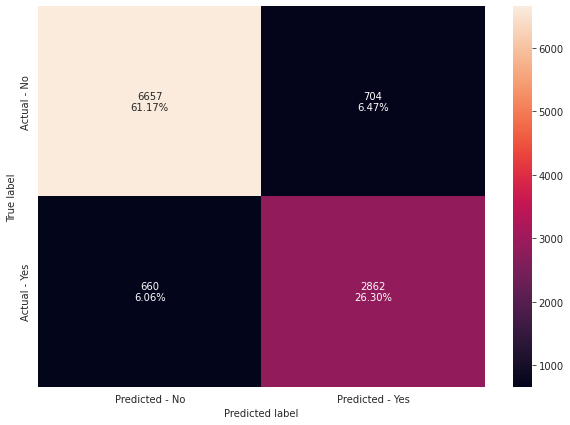

```python
make_confusion_matrix(dTree,y_test)
```

Observation:

Both false negatives and false positives are not ideal for the hotel. False negatives mean the company could overbook the room in anticipation of cancellation, which would not be ideal for brand loyalty and could lead lead to disgruntled customers if the hotel was oversold and no rooms were available, even though they made a reservation.

```python
# Recall on train and test
get_recall_score(dTree)
```

```
Recall on training set :  0.9866076766710511
Recall on test set :  0.8126064735945485
```

Observation: The decision tree is performing well on the test set, but is likely still overfit to the training set.

### Visualizing the Tree

```python
feature_names = list(X.columns)
print(feature_names)
```

```
['no_of_adults', 'no_of_children', 'no_of_weekend_nights', 'no_of_week_nights', 'required_car_parking_space', 'lead_time', 'arrival_year', 'arrival_month', 'arrival_date', 'repeated_guest', 'no_of_previous_cancellations', 'no_of_previous_bookings_not_canceled', 'avg_price_per_room', 'no_of_special_r…
```

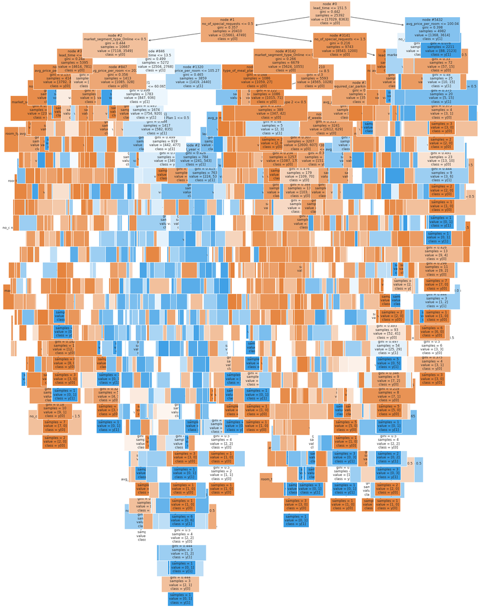

```python
plt.figure(figsize=(20,30))
tree.plot_tree(dTree,feature_names=feature_names,filled=True,fontsize=9,node_ids=True,class_names=True)
plt.show()
```

```python
# text report showing the rules of a decision tree -
print(tree.export_text(dTree,feature_names=feature_names,show_weights=True))
```

```
|--- lead_time <= 151.50
|   |--- no_of_special_requests <= 0.50
|   |   |--- market_segment_type_Online <= 0.50
|   |   |   |--- lead_time <= 90.50
|   |   |   |   |--- avg_price_per_room <= 201.50
|   |   |   |   |   |--- no_of_weekend_nights <= 0.50
|   |   |   |   |   |   |--- market_segment_type_Offline <= 0.50
|   |   |   |   |   |   |   |--- lead_time <= 16.50
|   |   |   |   |   |   |   |   |--- room_type_reserved_Room_Type 4 <= 0.50
|   |   |   |   |   |   |   |   |   |--- repeated_guest <= 0.50
|   |   |   |   |   |   |   |   |   |   |--- lead_time <= 11.50
|   |   |   |   |   |   |   |   |   |   |   |--- truncated branch of depth 13
|   |   |   |   |   |   |   |   |   |   |--- lead_time >  11.50
|   |   |   |   |   |   |   |   |   |   |   |--- truncated branch of depth 3
|   |   |   |   |   |   |   |   |   |--- repeated_guest >  0.50
|   |   |   |   |   |   |   |   |   |   |--- weights: [147.00, 0.00] class: 0
|   |   |   |   |   |   |   |   |--- room_type_reserved_Room_Type 4 >  0.50
|   |   |   |   |   |   |   |   |   |--- arrival_date <= 29.50
|   |   |   |   |   |   |   |   |   |   |--- no_of_adults <= 1.50
|   |   |   |   |   |   |   |   |   |   |   |--- truncated branch of depth 7
|   |   |   |   |   |   |   |   |   |   |--- no_of_adults >  1.50
|   |   |   |   |   |   |   |   |   |   |   |--- truncated branch of depth 2
|   |   |   |   |   |   |   |   |   |--- arrival_date >  29.50
|   |   |   |   |   |   |   |   |   |   |--- avg_price_per_room <= 76.00
|   |   |   |   |   |   |   |   |   |   |   |--- weights: [1.00, 0.00] class: 0
|   |   |   |   |   |   |   |   |   |   |--- avg_price_per_room >  76.00
|   |   |   |   |   |   |   |   |   |   |   |--- weights: [0.00, 3.00] class: 1
|   |   |   |   |   |   |   |--- lead_time >  16.50
|   |   |   |   |   |   |   |   |--- avg_price_per_room <= 135.00
|   |   |   |   |   |   |   |   |   |--- arrival_month <= 11.50
|   |   |   |   |   |   |   |   |   |   |--- lead_time <= 17.50
|   |   |   |   |   |   |   |   |   |   |   |--- truncated branch of depth 3
|   |   |   |   |   |   |   |   |   |   |--- lead_time >  17.50
|   |   |   |   |   |   |   |   |   |   |   |--- truncated branch of depth 12
|   |   |   |   |   |   |   |   |   |--- arrival_month >  11.50
|   |   |   |   |   |   |   |   |   |   |--- weights: [29.00, 0.00] class: 0
|   |   |   |   |   |   |   |   |--- avg_price_per_room >  135.00
|   |   |   |   |   |   |   |   |   |--- weights: [0.00, 8.00] class: 1
|   |   |   |   |   |   |--- market_segment_type_Offline >  0.50
|   |   |   |   |   |   |   |--- weights: [1609.00, 0.00] class: 0
```

[output cut: 1245 more lines]

```
|   |   |   |   |   |--- weights: [5.00, 0.00] class: 0
|   |   |   |   |--- arrival_date >  24.50
|   |   |   |   |   |--- room_type_reserved_Room_Type 1 <= 0.50
|   |   |   |   |   |   |--- lead_time <= 172.50
|   |   |   |   |   |   |   |--- room_type_reserved_Room_Type 4 <= 0.50
|   |   |   |   |   |   |   |   |--- weights: [0.00, 1.00] class: 1
|   |   |   |   |   |   |   |--- room_type_reserved_Room_Type 4 >  0.50
|   |   |   |   |   |   |   |   |--- weights: [2.00, 0.00] class: 0
|   |   |   |   |   |   |--- lead_time >  172.50
|   |   |   |   |   |   |   |--- weights: [0.00, 13.00] class: 1
|   |   |   |   |   |--- room_type_reserved_Room_Type 1 >  0.50
|   |   |   |   |   |   |--- no_of_weekend_nights <= 0.50
|   |   |   |   |   |   |   |--- weights: [0.00, 1.00] class: 1
|   |   |   |   |   |   |--- no_of_weekend_nights >  0.50
|   |   |   |   |   |   |   |--- weights: [3.00, 0.00] class: 0
```

```python
# importance of features in the tree building
print (pd.DataFrame(dTree.feature_importances_, columns = ["Imp"], index = X_train.columns).sort_values(by = 'Imp', ascending = False))
```

```
                                         Imp
lead_time                            0.35126
avg_price_per_room                   0.17332
market_segment_type_Online           0.09475
arrival_date                         0.08333
no_of_special_requests               0.06836
arrival_month                        0.06394
no_of_week_nights                    0.04558
no_of_weekend_nights                 0.03899
no_of_adults                         0.02578
arrival_year                         0.01173
type_of_meal_plan_Meal Plan 1        0.00755
required_car_parking_space           0.00679
room_type_reserved_Room_Type 4       0.00550
room_type_reserved_Room_Type 1       0.00503
type_of_meal_plan_Not Selected       0.00486
no_of_children                       0.00341
type_of_meal_plan_Meal Plan 2        0.00226
room_type_reserved_Room_Type 2       0.00149
market_segment_type_Offline          0.00145
room_type_reserved_Room_Type 5       0.00143
room_type_reserved_Room_Type 6       0.00071
no_of_previous_bookings_not_canceled 0.00061
room_type_reserved_Room_Type 7       0.00053
market_segment_type_Corporate        0.00052
market_segment_type_Aviation         0.00035
repeated_guest                       0.00035
no_of_previous_cancellations         0.00009
type_of_meal_plan_Meal Plan 3        0.00000
room_type_reserved_Room_Type 3       0.00000
market_segment_type_Complementary    0.00000
```

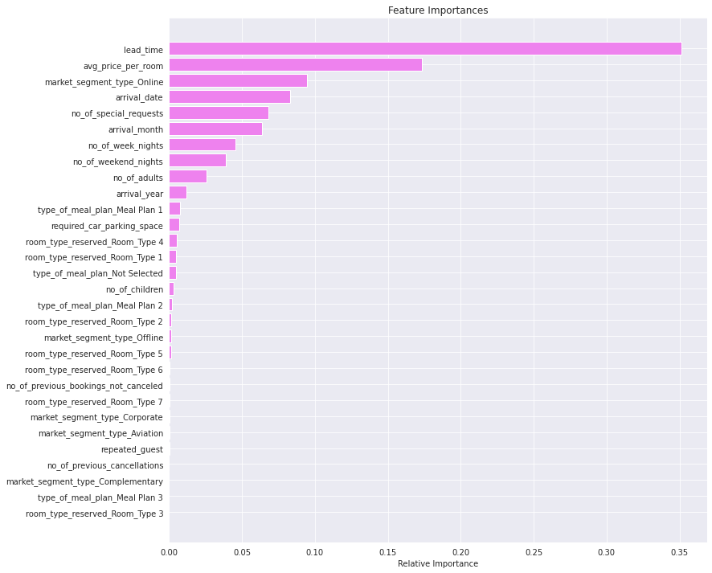

```python
# visualize feature importance
importances = dTree.feature_importances_
indices = np.argsort(importances)

plt.figure(figsize=(12,12))
plt.title('Feature Importances')
plt.barh(range(len(indices)), importances[indices], color='violet', align='center')
plt.yticks(range(len(indices)), [feature_names[i] for i in indices])
plt.xlabel('Relative Importance')
plt.show()
```

Observations: Lead time is the most important variable to consider when trying to predict cancellations.

## Do we need to prune the tree?

### Post-Pruning

Yes, the tree is very complex and it seems it may be overfitting on the training set. We should prune it. The deeper it is, the more complex it is, so we will post-pruning and try limiting max depth to 3.

```python
dTree1 = DecisionTreeClassifier(criterion = 'gini',max_depth=3,random_state=1)
dTree1.fit(X_train, y_train)
```

```
DecisionTreeClassifier(max_depth=3, random_state=1)
```

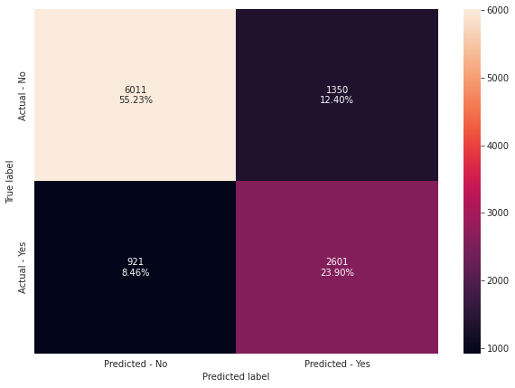

```python
# confusion matrix for max depth 3 tree
make_confusion_matrix(dTree1, y_test)
```

```python
# Accuracy on train and test for max depth 3
print("Accuracy on training set : ",dTree1.score(X_train, y_train))
print("Accuracy on test set : ",dTree1.score(X_test, y_test))
# Recall on train and test
get_recall_score(dTree1)
```

```
Accuracy on training set :  0.7844202898550725
Accuracy on test set :  0.7913259211614444
Recall on training set :  0.7315556618438359
Recall on test set :  0.7385008517887564
```

Observation: The recall went down considerably, but it is a good sign that the accuracy & recall measures are nearly similar on the training & test sets - it means our tree is not overfitting.

### Visualizing the Tree with Max Depth 3

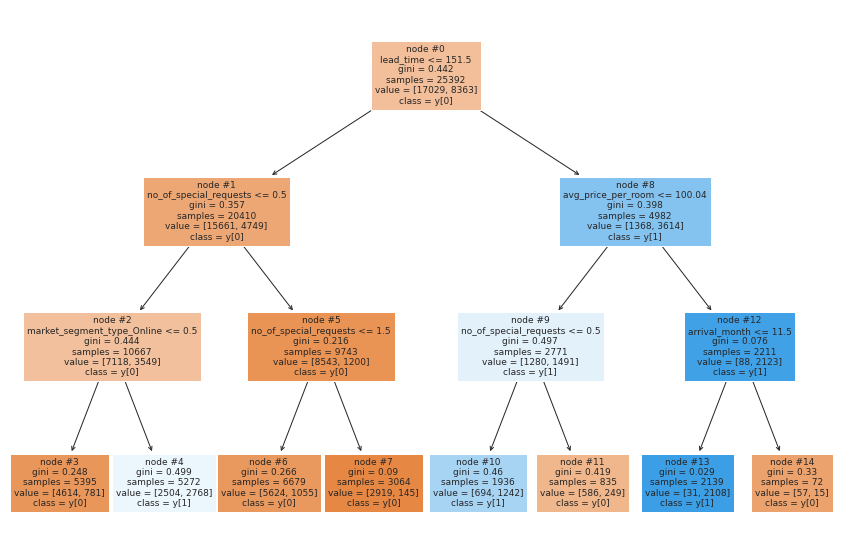

```python
plt.figure(figsize=(15,10))

tree.plot_tree(dTree1,feature_names=feature_names,filled=True,fontsize=9,node_ids=True,class_names=True)
plt.show()
```

Observation: We now have a much simpler, generalized tree model.

```python
# text report showing the rules of a decision tree
print(tree.export_text(dTree1,feature_names=feature_names,show_weights=True))
```

```
|--- lead_time <= 151.50
|   |--- no_of_special_requests <= 0.50
|   |   |--- market_segment_type_Online <= 0.50
|   |   |   |--- weights: [4614.00, 781.00] class: 0
|   |   |--- market_segment_type_Online >  0.50
|   |   |   |--- weights: [2504.00, 2768.00] class: 1
|   |--- no_of_special_requests >  0.50
|   |   |--- no_of_special_requests <= 1.50
|   |   |   |--- weights: [5624.00, 1055.00] class: 0
|   |   |--- no_of_special_requests >  1.50
|   |   |   |--- weights: [2919.00, 145.00] class: 0
|--- lead_time >  151.50
|   |--- avg_price_per_room <= 100.04
|   |   |--- no_of_special_requests <= 0.50
|   |   |   |--- weights: [694.00, 1242.00] class: 1
|   |   |--- no_of_special_requests >  0.50
|   |   |   |--- weights: [586.00, 249.00] class: 0
|   |--- avg_price_per_room >  100.04
|   |   |--- arrival_month <= 11.50
|   |   |   |--- weights: [31.00, 2108.00] class: 1
|   |   |--- arrival_month >  11.50
|   |   |   |--- weights: [57.00, 15.00] class: 0
```

```python
# print feature importance
print (pd.DataFrame(dTree1.feature_importances_, columns = ["Imp"], index = X_train.columns).sort_values(by = 'Imp', ascending = False))
```

```
                                         Imp
lead_time                            0.50191
market_segment_type_Online           0.19905
no_of_special_requests               0.16419
avg_price_per_room                   0.11313
arrival_month                        0.02172
room_type_reserved_Room_Type 5       0.00000
room_type_reserved_Room_Type 2       0.00000
room_type_reserved_Room_Type 3       0.00000
room_type_reserved_Room_Type 4       0.00000
room_type_reserved_Room_Type 7       0.00000
room_type_reserved_Room_Type 6       0.00000
type_of_meal_plan_Not Selected       0.00000
market_segment_type_Aviation         0.00000
market_segment_type_Complementary    0.00000
market_segment_type_Corporate        0.00000
market_segment_type_Offline          0.00000
room_type_reserved_Room_Type 1       0.00000
no_of_adults                         0.00000
type_of_meal_plan_Meal Plan 3        0.00000
no_of_children                       0.00000
type_of_meal_plan_Meal Plan 1        0.00000
no_of_previous_bookings_not_canceled 0.00000
no_of_previous_cancellations         0.00000
repeated_guest                       0.00000
arrival_date                         0.00000
arrival_year                         0.00000
required_car_parking_space           0.00000
no_of_week_nights                    0.00000
no_of_weekend_nights                 0.00000
type_of_meal_plan_Meal Plan 2        0.00000
```

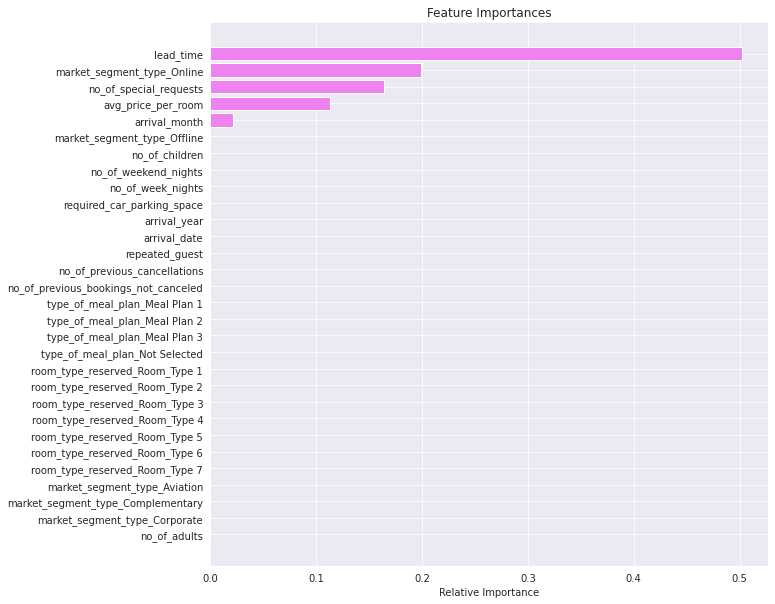

```python
# visualize feature importance
importances = dTree1.feature_importances_
indices = np.argsort(importances)

plt.figure(figsize=(10,10))
plt.title('Feature Importances')
plt.barh(range(len(indices)), importances[indices], color='violet', align='center')
plt.yticks(range(len(indices)), [feature_names[i] for i in indices])
plt.xlabel('Relative Importance')
plt.show()
```

Observation: The feature importance for this pruned tree is much more succint than the prior tree, which shows it is more generalized. Lead time is still out most important feature, which is good. However, now that we have avoided overfit, we may be underfitting. Let's see if we can pre-prune using gridsearch vs post-prune and get better performance values.

### Pre-pruning with Hyperparameter Tuning

```python
# Choose the type of classifier.
estimator = DecisionTreeClassifier(random_state=1)

# Grid of parameters to choose from
## add from article
parameters = {'max_depth': np.arange(1,10),
              'min_samples_leaf': [1, 2, 5, 7, 10,15,20],
              'max_leaf_nodes' : [2, 3, 5, 10],
              'min_impurity_decrease': [0.001,0.01,0.1]
             }

# Type of scoring used to compare parameter combinations
acc_scorer = metrics.make_scorer(metrics.recall_score)

# Run the grid search
grid_obj = GridSearchCV(estimator, parameters, scoring=acc_scorer,cv=5)
grid_obj = grid_obj.fit(X_train, y_train)

# Set the clf to the best combination of parameters
estimator = grid_obj.best_estimator_

# Fit the best algorithm to the data.
estimator.fit(X_train, y_train)
```

```
DecisionTreeClassifier(max_depth=3, max_leaf_nodes=5,
                       min_impurity_decrease=0.001, random_state=1)
```

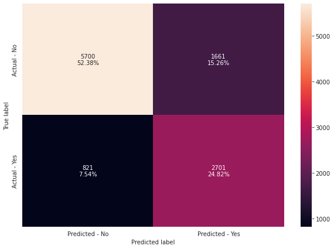

```python
# confusion matrix for the tree tuned with hyperparameters
make_confusion_matrix(estimator,y_test)
```

```python
# Accuracy on train and test
print("Accuracy on training set : ",estimator.score(X_train, y_train))
print("Accuracy on test set : ",estimator.score(X_test, y_test))
# Recall on train and test
get_recall_score(estimator)
```

```
Accuracy on training set :  0.7694943289224953
Accuracy on test set :  0.7719378847744188
Recall on training set :  0.7631232811192156
Recall on test set :  0.7668938103350369
```

Observation: The accuracy has dropped slightly on both the training and test sets, however the recall has increased slightly on both. Since we want to maximize recall, this decision tree model is performing even better than the post-pruned tree.

### Visualizing the Pre-Pruned (final model) Tree

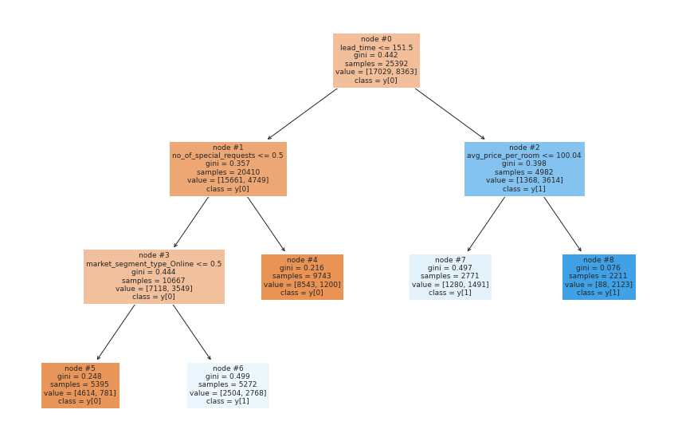

```python
plt.figure(figsize=(15,10))

tree.plot_tree(estimator,feature_names=feature_names,filled=True,fontsize=9,node_ids=True,class_names=True)
plt.show()
```

```python
# Text report showing the rules of a decision tree -

print(tree.export_text(estimator,feature_names=feature_names,show_weights=True))
```

```
|--- lead_time <= 151.50
|   |--- no_of_special_requests <= 0.50
|   |   |--- market_segment_type_Online <= 0.50
|   |   |   |--- weights: [4614.00, 781.00] class: 0
|   |   |--- market_segment_type_Online >  0.50
|   |   |   |--- weights: [2504.00, 2768.00] class: 1
|   |--- no_of_special_requests >  0.50
|   |   |--- weights: [8543.00, 1200.00] class: 0
|--- lead_time >  151.50
|   |--- avg_price_per_room <= 100.04
|   |   |--- weights: [1280.00, 1491.00] class: 1
|   |--- avg_price_per_room >  100.04
|   |   |--- weights: [88.00, 2123.00] class: 1
```

```python
# feature importance of final tree
print (pd.DataFrame(estimator.feature_importances_, columns = ["Imp"], index = X_train.columns).sort_values(by = 'Imp', ascending = False))
```

```
                                         Imp
lead_time                            0.53997
market_segment_type_Online           0.21415
no_of_special_requests               0.12418
avg_price_per_room                   0.12170
type_of_meal_plan_Not Selected       0.00000
market_segment_type_Offline          0.00000
market_segment_type_Corporate        0.00000
market_segment_type_Complementary    0.00000
market_segment_type_Aviation         0.00000
room_type_reserved_Room_Type 7       0.00000
room_type_reserved_Room_Type 6       0.00000
room_type_reserved_Room_Type 5       0.00000
room_type_reserved_Room_Type 4       0.00000
room_type_reserved_Room_Type 3       0.00000
room_type_reserved_Room_Type 2       0.00000
room_type_reserved_Room_Type 1       0.00000
no_of_adults                         0.00000
type_of_meal_plan_Meal Plan 3        0.00000
no_of_children                       0.00000
type_of_meal_plan_Meal Plan 1        0.00000
no_of_previous_bookings_not_canceled 0.00000
no_of_previous_cancellations         0.00000
repeated_guest                       0.00000
arrival_date                         0.00000
arrival_month                        0.00000
arrival_year                         0.00000
required_car_parking_space           0.00000
no_of_week_nights                    0.00000
no_of_weekend_nights                 0.00000
type_of_meal_plan_Meal Plan 2        0.00000
```

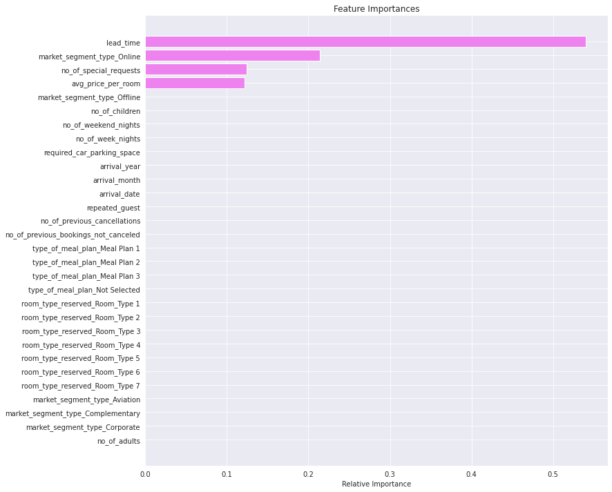

```python
# visualizing feature importance for the final tree
importances = estimator.feature_importances_
indices = np.argsort(importances)

plt.figure(figsize=(12,12))
plt.title('Feature Importances')
plt.barh(range(len(indices)), importances[indices], color='violet', align='center')
plt.yticks(range(len(indices)), [feature_names[i] for i in indices])
plt.xlabel('Relative Importance')
plt.show()
```

Observation: We can see that the importance of our root node increased a bit but the variable stayed the same (lead_time). We also see the tree was actually simplified even further and arrival_month is no longer an important feature as we now only have 4 vs 5.

## Model Performance Comparison and Conclusions

Our best logistic regression model achieved the following performance measures:

- Accuracy on the training set: 0.79
- Accuracy on the test set: 0.79
- Recall on the training set: 0.58
- Recall on the test set: 0.58

Whereas our best decision tree model achieved the following:

- Accuracy on the training set: 0.77
- Accuracy on the test set: 0.77
- Recall on the training set: 0.76
- Recall on the test set: 0.77

Accuracy is slightly better for the logistic regression model, but recall is significantly better for the decision tree model. Since we want to have high accuracy, but maximize recall, the decision tree model outperforms the logistic regression model.

## Actionable Insights and Recommendations

- What profitable policies for cancellations and refunds can the hotel adopt?
- What other recommedations would you suggest to the hotel?

We have built a solid model to predict which bookings are going to be cancelled and we suggest that the hotel implement it. They can use the results in several ways:

- They should consider enforcing a 'cancel-by' date and it can vary based on price of room, & other key indicators that a booking is more likely to be cancelled. This will help avoid cancellations too close to the date of stay and allow an opportunity to rebook. It will also limit cancellations made close to they stay as the guest would have to pay some sort of fee.
- They can consider different cancellation policies for various room types and meal plans.
- They can consider various cancellation policies by market segment type - maybe bookings made online cannot be cancelled online but have to be cancelled over the phone. This could limit guests froom booking a stay while still 'shopping around' at other properties for better prices and coming back to easily cancel online for free. Sometimes when you require someone to talk to an agent, they will forego the hassle altogether.
- Since repeat guests are less likely to cancel their stay, the hotel could consider giving returning guests higher cancellation 'privileges.' This would make them feel valued as a customer, and likely would not have an adverse impact on cancellations or profit.

```python
%%shell
jupyter nbconvert --to html /content/Project_SLC_DSBA_INNHotels_FullCode.ipynb
```

```
[NbConvertApp] Converting notebook /content/Project_SLC_DSBA_INNHotels_FullCode.ipynb to html
[NbConvertApp] Writing 2317328 bytes to /content/Project_SLC_DSBA_INNHotels_FullCode.html
```